# Analisis Data nafld menggunakan Analisis Survival

### Deskripsi Data

Data nafld1 merupakan data yang berisi data dari studi populasi penyakit hati berlemak non-alkohol (NAFLD). Subjek dengan kondisi dan serangkaian subjek kontrol yang cocok diikuti ke depan untuk kondisi metabolik, titik akhir jantung, dan kematian.

Variabel yang digunakan dalam analisis ini adalah

id: id subjek  
Age: umur  
Male: 0= perempuan, 1= laki-laki  
Weight: berat badan  
Height: tinggi badan  
Bmi: index massa tubuh  
Case.id: id dari data NAFLD  
Futime: waktu ke kejadian kematian atau followpu terakhir  
Status: 0 = hidup, 1= dead. (0=tersensor)

```r
## Load Package
library(survival)
library(survminer)
library(concordance)
options(scipen=999)
```

```r
## Load data
data(nafld)
head(nafld1)
```

|  | id | age | male | weight | height | bmi | case.id | futime | status |
| --- | --- | --- | --- | --- | --- | --- | --- | --- | --- |
| 3631 | 1 | 57 | 0 | 60.0 | 163 | 22.69094 | 10630 | 6261 | 0 |
| 8458 | 2 | 67 | 0 | 70.4 | 168 | 24.88403 | 14817 | 624 | 0 |
| 6298 | 3 | 53 | 1 | 105.8 | 186 | 30.45354 | 3 | 1783 | 0 |
| 15398 | 4 | 56 | 1 | 109.3 | 170 | 37.83010 | 6628 | 3143 | 0 |
| 13261 | 5 | 68 | 1 | NA | NA | NA | 1871 | 1836 | 1 |
| 14423 | 6 | 39 | 0 | 63.9 | 155 | 26.61559 | 7144 | 1581 | 0 |

```r
df = nafld1
head(df)
```

|  | id | age | male | weight | height | bmi | case.id | futime | status |
| --- | --- | --- | --- | --- | --- | --- | --- | --- | --- |
| 3631 | 1 | 57 | 0 | 60.0 | 163 | 22.69094 | 10630 | 6261 | 0 |
| 8458 | 2 | 67 | 0 | 70.4 | 168 | 24.88403 | 14817 | 624 | 0 |
| 6298 | 3 | 53 | 1 | 105.8 | 186 | 30.45354 | 3 | 1783 | 0 |
| 15398 | 4 | 56 | 1 | 109.3 | 170 | 37.83010 | 6628 | 3143 | 0 |
| 13261 | 5 | 68 | 1 | NA | NA | NA | 1871 | 1836 | 1 |
| 14423 | 6 | 39 | 0 | 63.9 | 155 | 26.61559 | 7144 | 1581 | 0 |

### Kurva Kaplan Meyer

Kurva kaplan meyer menggambarkan banyaknya kematian di setiap titik-titik waktu.Berikut merupakan cara membuat tabel kaplan meyer secara mandiri manual.

```r
### Tabel Kaplan Meyer
fit <- survfit(Surv(futime, status)~1, data = df)
surv_table <- data.frame(time=fit$time,
                         n_risk=fit$n.risk,
                         n_event=fit$n.event,
                         n_censor=fit$n.censor,
                         sur_prob=fit$surv)
surv_table
```

| time | n_risk | n_event | n_censor | sur_prob |
| --- | --- | --- | --- | --- |
| 7 | 17549 | 0 | 3 | 1.0000000 |
| 9 | 17546 | 0 | 3 | 1.0000000 |
| 10 | 17543 | 1 | 4 | 0.9999430 |
| 11 | 17538 | 1 | 2 | 0.9998860 |
| 12 | 17535 | 0 | 1 | 0.9998860 |
| 13 | 17534 | 0 | 2 | 0.9998860 |
| 15 | 17532 | 2 | 0 | 0.9997719 |
| 17 | 17530 | 1 | 0 | 0.9997149 |
| 18 | 17529 | 0 | 1 | 0.9997149 |
| 19 | 17528 | 0 | 4 | 0.9997149 |

[output cut: 990 more lines]

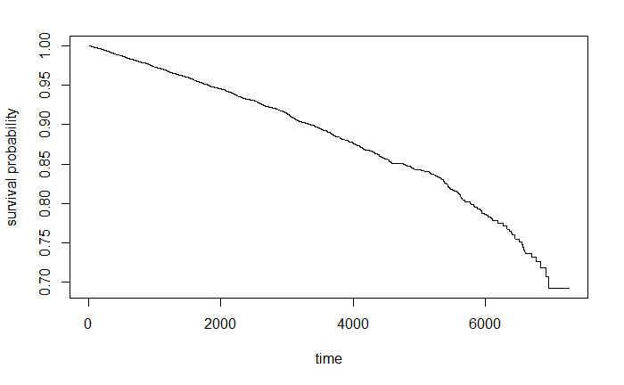

```r
### Kurva Kaplan Meyer
plot(x=surv_table$time,
     y=surv_table$sur_prob,
     type="l",
     ylab="survival probability",
     xlab="time")
```

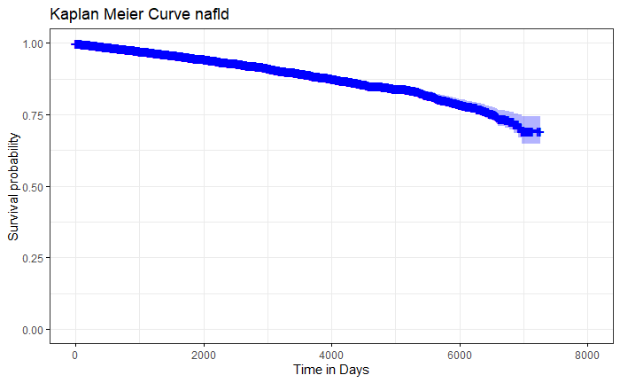

```r
### Kurva Kaplan meyer
ggsurvplot(fit,
           ggtheme = theme_bw(),
           palette="blue",
           legend="none",
           xlab = "Time in Days") +
  ggtitle("Kaplan Meier Curve nafld")
```

### Kurva Kaplan Meyer (breakdown berdasarkan data kategori)

Kurva kaplan meyer juga bisa membandingkan apakah terdapat perbedaan survival antara dua kelas. Contohnya gender, apakah terdapat perbedaan survival antara perempuan dan laki-laki.

[figure not shown]

```r
fit2 <- survfit(Surv(futime, status)~male, data = df)
ggsurvplot(fit2,
           pval = TRUE,
           ggtheme = theme_bw(),
           palette = c("red","blue"),
           legend="left",
           legend.labs = c("Male", "Female"),
           xlab = "Time in Days") +
  ggtitle("Kaplan Meier Curve Lung Dataset")
```

Karena pvalue = 0.00078 < 0.05 maka dapat dikatakan bahwa terdapat perbedaan waktu kejadian kematian perrempuan dan laki-laki.

### Model Cox Proportional Hazard

Merupakan model regresi yang digunakan untuk mengidentifikasi hubungan antara waktu survival dan satu atau lebih variabel prediktor.

```r
options(scipen=999)
df$male <- as.factor(df$male) # convert to dummy variable
model_coxph <- coxph (Surv(futime, status) ~ age + male + weight +  height +
                       bmi,data=df)

summary(model_coxph)
```

```
Call:
coxph(formula = Surv(futime, status) ~ age + male + weight +
    height + bmi, data = df)

  n= 12588, number of events= 1018
   (4961 observations deleted due to missingness)

            coef exp(coef)  se(coef)      z             Pr(>|z|)
age     0.098330  1.103327  0.002771 35.483 < 0.0000000000000002 ***
male1   0.550169  1.733547  0.091513  6.012        0.00000000183 ***
weight  0.009734  1.009781  0.012206  0.797                0.425
height -0.022267  0.977979  0.013629 -1.634                0.102
bmi    -0.011134  0.988927  0.033234 -0.335                0.738
---
Signif. codes:  0 ‘***’ 0.001 ‘**’ 0.01 ‘*’ 0.05 ‘.’ 0.1 ‘ ’ 1

       exp(coef) exp(-coef) lower .95 upper .95
age       1.1033     0.9063    1.0974     1.109
male1     1.7335     0.5769    1.4489     2.074
weight    1.0098     0.9903    0.9859     1.034
height    0.9780     1.0225    0.9522     1.004
bmi       0.9889     1.0112    0.9266     1.055

Concordance= 0.828  (se = 0.007 )
Likelihood ratio test= 1758  on 5 df,   p=<0.0000000000000002
Wald test            = 1489  on 5 df,   p=<0.0000000000000002
Score (logrank) test = 1729  on 5 df,   p=<0.0000000000000002
```

Jika pvalue < 0.05 maka dapat dikatakan bahwa variabel tersebut mempengaruhi waktu survival. Sehingga variabel yang mempenagaruhi adalah umur dan jenis kelamin.

### Survival Model Regresion

Model Coxph merupakan semi-parametrik model, artinya variabel waktu survival tidak diasumsikan berdistribusi tertentu. Sedangkan suvreg adalah model parametrik yang mengasumsikan bahwa waktu survival mengikuti distribusi tertentu.

```r
options(scipen=999)
df$male <- as.factor(df$male) # convert to dummy variable
model_exp <- survreg(Surv(futime, status) ~ age + male + weight +  height +
                        bmi,dist="exponential",data=df)

summary(model_exp)
```

```
Call:
survreg(formula = Surv(futime, status) ~ age + male + weight +
    height + bmi, data = df, dist = "exponential")
               Value Std. Error      z                    p
(Intercept) 12.63031    2.22604   5.67         0.0000000140
age         -0.09252    0.00265 -34.91 < 0.0000000000000002
male1       -0.53499    0.09073  -5.90         0.0000000037
weight      -0.01029    0.01193  -0.86                0.389
height       0.02419    0.01340   1.81                0.071
bmi          0.01422    0.03245   0.44                0.661

Scale fixed at 1

Exponential distribution
Loglik(model)= -10669.3   Loglik(intercept only)= -11502.9
    Chisq= 1667.3 on 5 degrees of freedom, p= 0
Number of Newton-Raphson Iterations: 7
n=12588 (4961 observations deleted due to missingness)
```

Jika pvalue < 0.05 maka dapat dikatakan bahwa variabel tersebut mempengaruhi waktu survival. Sehingga variabel yang mempenagaruhi adalah umur dan jenis kelamin. Dapat dikatakan bahwa model tersebut menghasilkan keputussan yang sama.

### Concordance

merupakan suatu metrik untuk mengevaluasi prediksi. Concordance berkisar antara 0 dan 1. Jika Concordance = 0 maka prediksi salah semua, sedangkan Concordance = 1 maka prediksi sangat tepat.

```r
concordance(model_coxph)
```

```
Call:
concordance.coxph(object = model_coxph)

n= 12588
Concordance= 0.8281 se= 0.007028
concordant discordant     tied.x     tied.y    tied.xy
   6415282    1331979          1        146          0
```

Karena nilai concordance = 0.8281 (mendekati 1) maka dapat dikatakan bahwa pediksi cukup bagus (ketepatan prediksi sebesar 82%).

```r
concordance(model_exp)
```

```
Call:
concordance.survreg(object = model_exp)

n= 12588
Concordance= 0.8281 se= 0.007029
concordant discordant     tied.x     tied.y    tied.xy
   6415221    1332040          1        146          0
```

Karena nilai concordance = 0.8281 (mendekati 1) maka dapat dikatakan bahwa pediksi cukup bagus (ketepatan prediksi sebesar 82%).